# Final Project

Fomba Kassoh & Souleymane Doumbia

2023-12-10

# Abstract

The analysis provides a comprehensive examination of audiobook data. It employs web scraping techniques, utilizing Selenium and Scraper Spider, to gather audiobook information. The data, initially saved as CSV and JSON, is processed using R, following the OSEMN framework and Hadley Wickham’s Grammar of Data Science. Key tasks include data tidying, parsing, cleaning, and transformation for thorough analysis.

Significant efforts are made to parse and clean fields like ‘authors’ and ‘narrators’, extract numeric data from ‘length’, ‘rating’, and ‘no_of_ratings’, and standardize ‘release_date’ and ‘language’. Price fields are also formatted, and a ‘sales_status’ column is added.

The analysis delves into audiobook length, revealing a user preference for roughly 9-hour long books, and examines rating distribution, showing a skew towards high ratings. The relationship between audiobook length and ratings is explored, showing a minor negative correlation, suggesting length has only a marginal impact on ratings. The distribution of the number of ratings highlights a concentration of popularity among specific titles.

Author and narrator popularity are analyzed, indicating clear hierarchies and influence on the market. Sentiment analysis using Scrapy data reviews reveals predominantly positive sentiments towards the audiobooks.

# Introduction

This project delves into the analysis of audiobooks as follow:

## Context of data Collection

Acquired data through web scraping using the following frameworks:

- **Selenium:** The data scrapped by Selenium is dirtier on purpose to:
  1. *Demostrate data tidying.*
  2. *Data visualization.*
  3. *Exploratory data analysis.*
- **Scraper Spider:** The Spider data is cleaner on purpose to:
  1. *Create a joint with the Selenium data*
  2. *For sentiment analysis.*

## Preview of Scraping code:

- **The preview shows Scrapy code:**

https://raw.githubusercontent.com/hawa1983/DATA607_Final_project/main/audible.py

- **The preview shows Selenium code:**

https://raw.githubusercontent.com/hawa1983/DATA607_Final_project/main/audible_selenium_v2.py

## Post-acquisition

The project follows the OSEMN framework and Hadley Wickham’s Grammar of Data Science.

- **The data, initially scraped and saved as CSV and json files**
- **The data is further processed in R for:**
  1. *data tidying/cleaning,*
  2. *parsing, and transformation,*
  3. *preparing it for comprehensive analysis.*
- **Detailed exploratory and analytical work in R.**

```r
# Loading libraries
library(readr)
library(tidyr)
library(dplyr)
library(stringr)
```

# Overview of the data

Below are the variables in the data. The data scraped by Scraper further has:

```r
audible_books <- read_csv("https://raw.githubusercontent.com/hawa1983/DATA607/main/audible_books.csv")
glimpse(audible_books)
```

```
## Rows: 500
## Columns: 15
## $ title         <chr> "He's Not My Type", "Thesaurize", "Moral Stand", "LLC Be…
## $ subtitle      <chr> "Vancouver Agitators Series, Book 4", "The Completionist…
## $ authors       <chr> "['Meghan Quinn']", "['Dakota Krout']", "['Daniel Schinh…
## $ narrators     <chr> "['Connor Crais', 'Erin Mallon', 'Teddy Hamilton', 'Jaso…
## $ series        <chr> "The Vancouver Agitators", "The Completionist Chronicles…
## $ length        <chr> "Length: 11 hrs and 40 mins", "Length: 11 hrs and 40 min…
## $ release_date  <chr> "Release date: 11-28-23", "Release date: 11-06-23", "Rel…
## $ language      <chr> "Language: English", "Language: English", "Language: Eng…
## $ rating        <chr> "5 out of 5 stars", "5 out of 5 stars", "5 out of 5 star…
## $ no_of_ratings <chr> "362 ratings", "328 ratings", "164 ratings", "51 ratings…
## $ regular_price <chr> "$24.95", "$24.95", "$24.95", "$14.95", "$14.95", "$19.9…
## $ sales_price   <lgl> NA, NA, NA, NA, NA, NA, NA, NA, NA, NA, NA, NA, NA, NA, …
## $ category      <lgl> NA, NA, NA, NA, NA, NA, NA, NA, NA, NA, NA, NA, NA, NA, …
## $ genres        <chr> "[]", "[]", "[]", "[]", "[]", "[]", "[]", "[]", "[]", "[…
## $ url           <chr> "https://www.audible.com/pd/Hes-Not-My-Type-Audiobook/B0…
```

# Data Tydying

## Parsing and Cleaning ‘authors’, ‘narrators’

Parse and clean the ‘authors’ and ‘narrators’ fields using str_replace_all to remove unwanted characters and extract the necessary information.

- **Cleans up the ‘authors’ and ‘narrators’ columns.**
- **Relocates the cleaned columns next to the originals.**
- **Drops the original ‘authors’ and ‘narrators’ columns.**
- **Renames the cleaned columns to ‘authors’ and ‘narrators’.**
- **Select affected columns for display only**

```r
# Cleaning 'authors' and 'narrators', relocating them, dropping the original, and renaming the cleaned columns
audible_books <- audible_books %>%
  mutate(
    authors_cleaned = str_replace_all(authors, "\\['|'\\]", ""),
    narrators_cleaned = str_replace_all(narrators, "\\['|'\\]", "")
  ) %>%
  relocate(authors_cleaned, .after = authors) %>%
  relocate(narrators_cleaned, .after = narrators) %>%
  select(-authors, -narrators) %>%
  rename(
    authors = authors_cleaned,
    narrators = narrators_cleaned
  )

#audible_books %>%
#  select(title, authors, narrators) %>%
#  head()
```

## Extracting Numeric Data from ‘length’, ‘rating’, and ‘no_of_ratings’

We will tidy these columns as follows:

- **Extract the numeric data from the ‘length’, ‘rating’, and ‘no_of_ratings’ columns.**
- **We’ll use str_extract to pull out the numbers, and for the ‘rating’.**
- **We’ll also remove the ‘out of 5 stars’ text.**
- **Select the affected columns for display only**

```r
library(dplyr)
library(stringr)

audible_books <- audible_books %>%
  mutate(
    # Extracting hours and convert to numeric, replacing NA with 0 if only minutes are present
    length_hours = as.numeric(str_extract(length, "\\b\\d+\\b(?=\\s*hr)")) %>% replace_na(0),
    # Extracting minutes and convert to numeric, replacing NA with 0 if only hours are present
    length_minutes = as.numeric(str_extract(length, "\\b\\d+\\b(?=\\s*min)")) %>% replace_na(0),
    # Calculating total length in minutes
    total_length_minutes = (length_hours * 60) + length_minutes,
    # Extracting numeric rating and number of ratings
    rating_numeric = as.numeric(str_extract(rating, "\\b\\d+(\\.\\d+)?")),
    no_of_ratings_numeric = as.numeric(str_extract(no_of_ratings, "\\b\\d+"))
  ) %>%
  select(-length_hours, -length_minutes) %>%
  relocate(total_length_minutes, .after = length) %>%
  relocate(rating_numeric, .after = rating) %>%
  relocate(no_of_ratings_numeric, .after = no_of_ratings)

#audible_books %>%
#  select(length, total_length_minutes, rating, rating_numeric, no_of_ratings, no_of_ratings_numeric) %>%
#  head()
```

## Standardizing ‘release_date’ and ‘language’:

- **Extracts and converts the ‘release_date’ to a date format.**
- **Extracts the language name from the ‘language’ field.**
- **Relocates the standardized columns next to the originals.**
- **Drops the original ‘release_date’ and ‘language’ columns.**
- **Renames the standardized columns to ‘release_date’ and ‘language’.**
- **Select the affected columns for display only**

```r
# Standardizing 'release_date' and extracting just the language name from 'language', rearranging them, dropping the original, and renaming them
audible_books <- audible_books %>%
  mutate(
    release_date_standardized = as.Date(str_extract(release_date, "\\d{2}-\\d{2}-\\d{2,4}"), format = "%m-%d-%y"),
    language_standardized = str_replace(language, "Language: ", "")
  ) %>%
  relocate(release_date_standardized, .after = release_date) %>%
  relocate(language_standardized, .after = language) %>%
  select(-release_date, -language) %>%
  rename(
    release_date = release_date_standardized,
    language = language_standardized
  )

#audible_books %>%
#  head()
```

## Formatting Price Fields

- **The regular_price_numeric and sales_price_numeric columns are created by extracting the numeric values from ‘regular_price’ and ‘sales_price’.**
- **Create a sales_status column based on whether sales_price_numeric is NA or not.**
- **Relocated next to their respective original columns.**
- **Remove the original ‘regular_price’ and ‘sales_price’ from the dataframe**
- **Select the affected columns for display only**

```r
# Processing 'regular_price' and 'sales_price', create 'sales_status' column, rearrange, drop the original, and rename
audible_books <- audible_books %>%
  mutate(
    regular_price_numeric = as.numeric(str_extract(regular_price, "\\d+\\.\\d+")),
    sales_price_numeric = as.numeric(str_extract(sales_price, "\\d+\\.\\d+")),
    sales_status = ifelse(is.na(sales_price_numeric), "not on sale", "on sale")
  ) %>%
  relocate(regular_price_numeric, .after = regular_price) %>%
  relocate(sales_price_numeric, .after = sales_price) %>%
  relocate(sales_status, .after = sales_price_numeric) %>%
  select(-regular_price, -sales_price)

#audible_books %>%
#  select(regular_price_numeric, sales_price_numeric, sales_status) %>%
 # head()
```

# Audiobook Length Analysis

```r
library(ggplot2)
# Summary statistics for audiobook lengths
length_summary <- summary(audible_books$total_length_minutes)
length_summary
```

```
##    Min. 1st Qu.  Median    Mean 3rd Qu.    Max.
##    31.0   369.8   532.0   579.4   697.0  2762.0
```

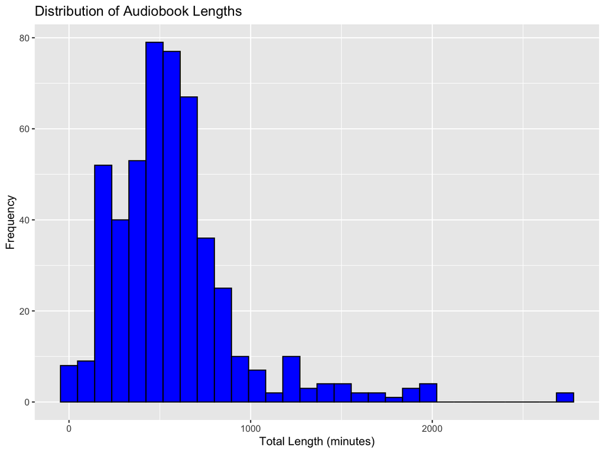

```r
# Histogram of audiobook lengths
ggplot(audible_books, aes(x = total_length_minutes)) +
  geom_histogram(bins = 30, fill = "blue", color = "black") +
  labs(title = "Distribution of Audiobook Lengths", x = "Total Length (minutes)", y = "Frequency")
```

The histogram of audiobook lengths shows:

- **a concentration of audiobooks under 700 minutes, with a median of 532 minutes.**
- **This indicates a user preference for audiobooks around 9 hours long, suitable for consuming in a day or a week.**
- **The mean length is slightly higher at 579 minutes, hinting at longer audiobooks influencing the average.**
- **With the longest audiobook at 2762 minutes, there’s content for users who enjoy extensive listening.**
- **The distribution suggests a varied catalog with a focus on moderate-length audiobooks.**

# Rating Distribution

```r
# Summary statistics for audiobook lengths
rating_summary <- summary(audible_books$rating_numeric)
rating_summary
```

```
##    Min. 1st Qu.  Median    Mean 3rd Qu.    Max.
##   4.500   4.500   5.000   4.843   5.000   5.000
```

```r
rating_frequency <- audible_books %>% select (rating_numeric) %>% group_by(rating_numeric) %>% count()
rating_frequency
```

```
## # A tibble: 2 × 2
## # Groups:   rating_numeric [2]
##   rating_numeric     n
##            <dbl> <int>
## 1            4.5   157
## 2            5     343
```

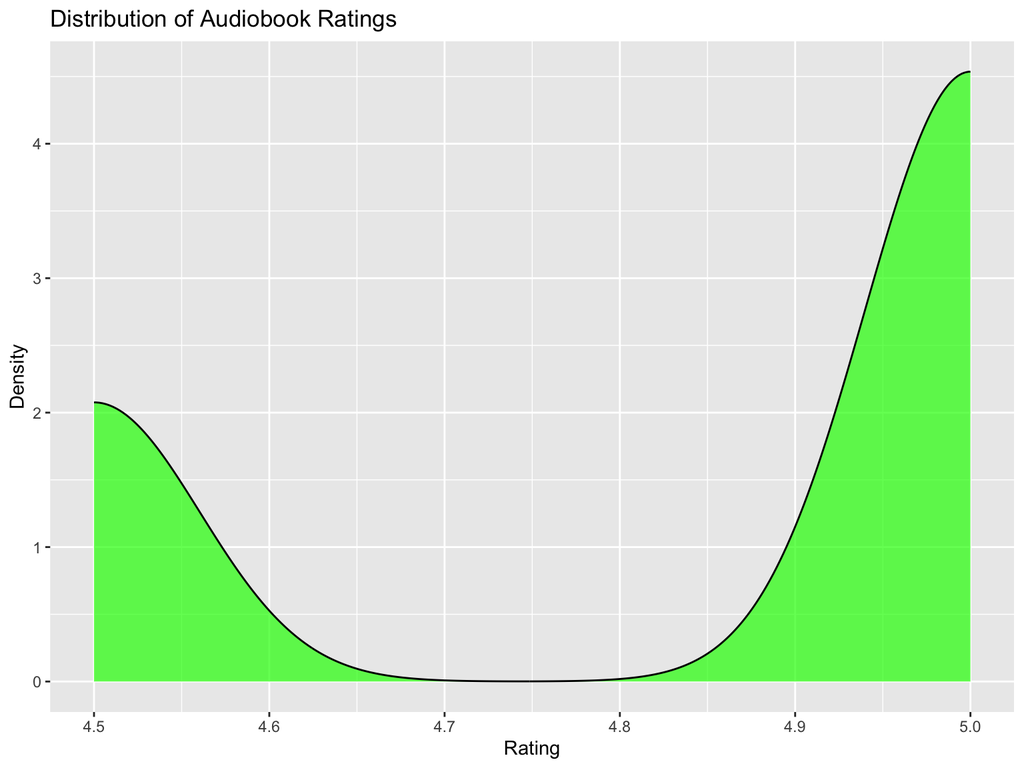

```r
# Histogram or density plot of audiobook ratings
ggplot(audible_books, aes(x = rating_numeric)) +
 #geom_histogram(bins = 30, fill = "grey", color = "purple") +
  geom_density(fill = "green", alpha = 0.7) +
  labs(title = "Distribution of Audiobook Ratings", x = "Rating", y = "Density")
```

The density plot of audiobook ratings shows:

- **a strong skew towards high ratings, with a peak at 5.0 indicating a large number of audiobooks receiving perfect scores.**
- **This concentration of high ratings suggests either a selection of high-quality titles or a tendency among users to rate audiobooks favorably.**
- **The mean rating is 4.84, supporting this trend towards higher ratings.**
- **The range is narrow, with the lowest rating at 4.5, showcasing overall positive reception.**
- **The data indicates users of this audiobook platform are likely to encounter content that is well-received by others, which could be a strong selling point for the service.**

# Number of Rating Distribution

```r
# Summary statistics for Number Of Rating
number_ofRating_summary <- summary(audible_books$no_of_ratings_numeric)
number_ofRating_summary
```

```
##    Min. 1st Qu.  Median    Mean 3rd Qu.    Max.
##    6.00   11.00   15.00   28.31   25.00  973.00
```

```r
frequency <- audible_books %>% select(no_of_ratings_numeric) %>% group_by(no_of_ratings_numeric) %>% count()
frequency
```

```
## # A tibble: 64 × 2
## # Groups:   no_of_ratings_numeric [64]
##    no_of_ratings_numeric     n
##                    <dbl> <int>
##  1                     6     5
##  2                     7    24
##  3                     8    38
##  4                     9    41
##  5                    10    16
##  6                    11    17
##  7                    12    29
##  8                    13    29
##  9                    14    29
## 10                    15    27
## # ℹ 54 more rows
```

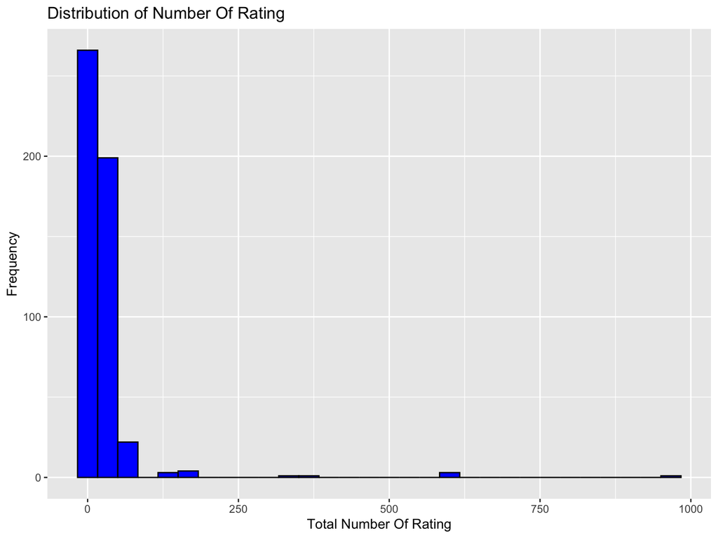

```r
# Histogram of Number Of Rating
ggplot(audible_books, aes(x = no_of_ratings_numeric)) +
  geom_histogram(bins = 30, fill = "blue", color = "black") +
  labs(title = "Distribution of Number Of Rating", x = "Total Number Of Rating", y = "Frequency")
```

The “Distribution of Number Of Rating” histogram, together with the R console’s summary statistics, provides a concise visual and quantitative analysis of the audiobook ratings count in the dataset:

- **The bulk of audiobooks receive fewer ratings, with frequency declining as the number of ratings increases,**
- **This points to a select few audiobooks attracting a high volume of ratings.**
- **The summary further details that the median is at 15, suggesting half of the audiobooks have 15 or fewer ratings.**
- **The mean is slightly elevated at 28.3 due to the influence of a few highly-rated audiobooks.**
- **This disparity between the mean and median indicates the skewed nature of the distribution.**
- **Additionally, the first and third quartiles stand at 11 and 25 ratings respectively, revealing that 25% of the audiobooks have fewer than 11 ratings, and 75% have fewer than 25.**
- **This insight reflects on the listeners’ engagement, suggesting a concentration of popularity among a small number of titles and potentially highlighting a need for further promotion or time to accumulate ratings for the others.**

# Relationship Between Ratings and Length

```r
# Correlation analysis between ratings and total length
correlation_length_rating <- cor(audible_books$rating_numeric, audible_books$total_length_minutes, use = "complete.obs")
correlation_length_rating
```

```
## [1] -0.1490941
```

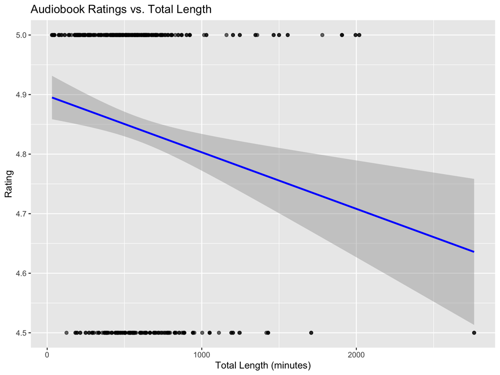

```r
# Scatter plot of ratings vs total length
ggplot(audible_books, aes(x = total_length_minutes, y = rating_numeric)) +
  geom_point(alpha = 0.6) +
  geom_smooth(method = "lm", color = "blue") +
  labs(title = "Audiobook Ratings vs. Total Length", x = "Total Length (minutes)", y = "Rating")
```

The scatter plot depicts Audiobook Ratings vs. Total Length:

- **The correlation coefficient of -0.1491 indicates a minor negative relationship between an audiobook’s length and its ratings**
- **This relationship is not strong. This trend suggests that longer audiobooks may receive marginally lower ratings on average,**
- **but the correlation is weak, which points to other factors likely playing a more pivotal role in determining ratings.**

# Relationship Between Ratings and Number of Ratings

```r
# Correlation analysis between ratings and number of ratings
correlation_result <- cor(audible_books$rating_numeric, audible_books$no_of_ratings_numeric, use = "complete.obs")
correlation_result
```

```
## [1] -0.1603486
```

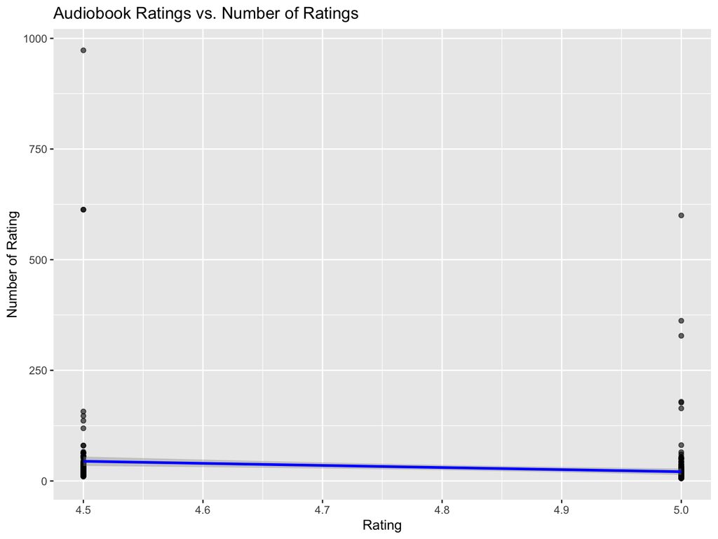

```r
# Scatter plot of ratings vs number of ratings
ggplot(audible_books, aes(x = rating_numeric, y = no_of_ratings_numeric)) +
  geom_point(alpha = 0.6) +
  geom_smooth(method = "lm", color = "blue") +
  labs(title = "Audiobook Ratings vs. Number of Ratings", x = "Rating", y = "Number of Rating")
```

Analysis of the audiobook dataset reveals a landscape where:

- **a few titles receive a high number of ratings, but most accumulate fewer engagements.**
- **This trend is supported by the scatterplot which, with a slight negative correlation, suggests that higher-rated audiobooks do not always equate to higher engagement.**
- **These insights are essential for understanding the distribution of listener engagement across the audiobook collection, highlighting potential areas for strategic marketing and positioning within the audiobook market.**

# Author and Narrator Popularity Analysis

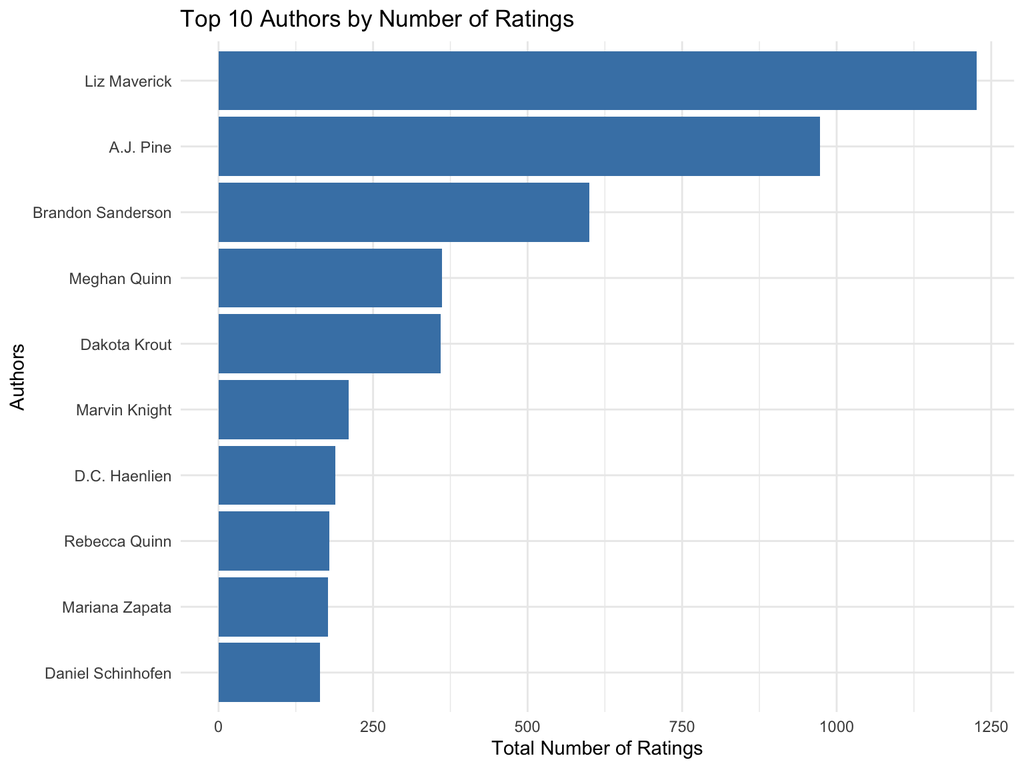

```r
# Calculate average ratings and number of ratings by author
author_popularity <- audible_books %>%
  group_by(authors) %>%
  summarise(
    average_rating = mean(rating_numeric, na.rm = TRUE),
    total_ratings = sum(no_of_ratings_numeric, na.rm = TRUE)
  ) %>%
  arrange(desc(total_ratings))

# Top 10 authors by total ratings
top_authors <- head(author_popularity, 10)

ggplot(top_authors, aes(x = reorder(authors, total_ratings), y = total_ratings)) +
  geom_bar(stat = "identity", fill = "steelblue") +
  coord_flip() + # Flips the axes to make labels readable
  labs(x = "Authors", y = "Total Number of Ratings", title = "Top 10 Authors by Number of Ratings") +
  theme_minimal()
```

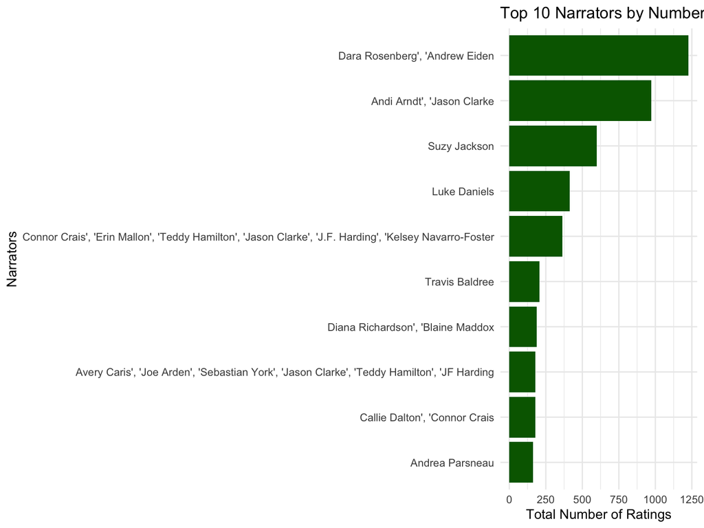

```r
# Calculate average ratings and number of ratings by narrator
narrator_popularity <- audible_books %>%
  group_by(narrators) %>%
  summarise(
    average_rating = mean(rating_numeric, na.rm = TRUE),
    total_ratings = sum(no_of_ratings_numeric, na.rm = TRUE)
  ) %>%
  arrange(desc(total_ratings))

# Top 10 narrators by total ratings
top_narrators <- head(narrator_popularity, 10)

ggplot(top_narrators, aes(x = reorder(narrators, total_ratings), y = total_ratings)) +
  geom_bar(stat = "identity", fill = "darkgreen") +
  coord_flip() +
  labs(x = "Narrators", y = "Total Number of Ratings", title = "Top 10 Narrators by Number of Ratings") +
  theme_minimal()
```

- **The authors’ chart presents, with the top authors receiving a high number of ratings, which could be reflective of their popularity, prolific output, or the success of specific titles**
- **In the narrators’chart, a similar trend, we see a clear hierarchy, with the most popular narrators receiving significantly more ratings than others, which indicates a high listener engagement and possibly a strong fan base**
- **These analyses serve as a powerful tool for understanding market trends, guiding marketing strategies, and possibly for recommending narrators and authors to listeners based on popular appeal.**
- **The insights from these charts suggest that certain narrators and authors have a significant influence on the audiobook market’s dynamics, potentially driving sales and popularity of the titles they are associated with.**

# Sentiment Analysys

We used the reviews from the scraped data using Scrapy for sentiment analysis

## Distribution of positive and negative Sentiments

The bar graph to shows the distribution of sentiments across reviews for audiobooks. Here’s an analysis based on the interpretation of the graph:

**Positive Sentiments:** The graph shows a large number of positive sentiments, indicated by the tall blue bar. This suggests that the majority of the reviews are positive, indicating a favorable reception from the reviewers.

**Implications:** For the provider of the products or services being reviewed, this distribution would generally be considered very good news. It may also suggest customer satisfaction and could potentially be used in marketing or product development to further enhance positive aspects or address the negative feedback.

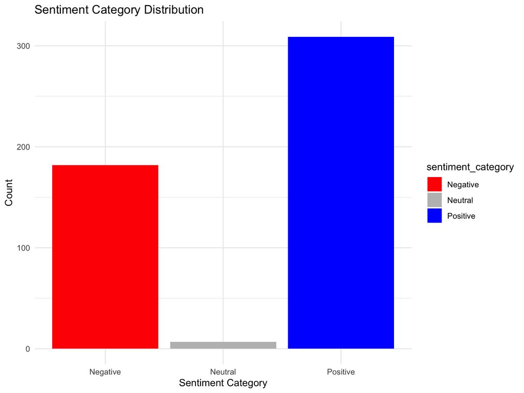

```r
# Load the necessary libraries
library(ggplot2)
library(dplyr)
library(readr)
library(syuzhet)

reviews_sentiments <- reviews_sentiments %>%
  mutate(sentiment_category = case_when(
    sentiment > 0 ~ "Positive",
    sentiment < 0 ~ "Negative",
    TRUE ~ "Neutral"
  ))

# Plot the distribution of sentiment categories
ggplot(reviews_sentiments, aes(x = sentiment_category, fill = sentiment_category)) +
  geom_bar() +
  scale_fill_manual(values = c("Positive" = "blue", "Negative" = "red", "Neutral" = "grey")) +
  labs(title = "Sentiment Category Distribution",
       x = "Sentiment Category",
       y = "Count") +
  theme_minimal()
```

# Distribution of Sentiments

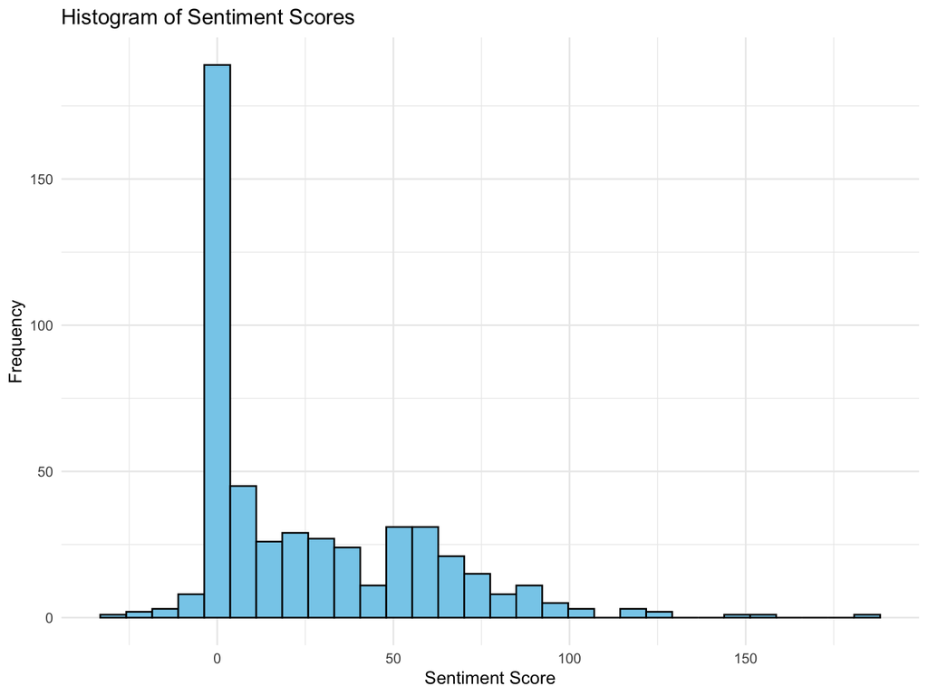

```r
# Load the necessary libraries
library(ggplot2)
library(dplyr)
library(readr)
library(syuzhet)


reviews_sentiments <- reviews_sentiments %>%
  mutate(sentiment_category = case_when(
    sentiment > 0 ~ "Positive",
    sentiment < 0 ~ "Negative",
    TRUE ~ "Neutral"
  ))


# plot the sentiment scores using a histogram
ggplot(reviews_sentiments, aes(x = sentiment)) +
  geom_histogram(bins = 30, fill = "skyblue", color = "black") +
  labs(title = "Histogram of Sentiment Scores",
       x = "Sentiment Score",
       y = "Frequency") +
  theme_minimal()
```

# Another sentiment analysis (sentimentr)

```r
library(sentimentr)
library(readr)
library(jsonlite)

# Read the CSV file into a DataFrame
reviews_sentiments <- read_csv("https://raw.githubusercontent.com/hawa1983/DATA607_Final_project/main/audible.csv", show_col_types = FALSE)


# Filter out rows where 'review_text' is NA
reviews_sentiments <- reviews_sentiments %>%
  filter(!is.na(reviews))

# Calculate the mean sentiment for each review
reviews_sentiments <- reviews_sentiments %>%
  rowwise() %>%
  mutate(
    # Calculate sentiment scores for non-NA review texts
    sentiment_score = mean(sentiment(get_sentences(reviews))$sentiment)
  ) %>%
  ungroup()

# Create a sentiment decision column based on sentiment_score
reviews_sentiments <- reviews_sentiments %>%
  mutate(
    sentiment_decision = case_when(
      sentiment_score > 0  ~ "positive",
      sentiment_score < 0  ~ "negative",
      TRUE ~ "neutral"
    )
  )

# Select the necessary columns
reviews_sentiments <- reviews_sentiments %>%
  select(title, sentiment_score, sentiment_decision)

head(reviews_sentiments, 10)
```

```
## # A tibble: 10 × 3
##    title                                    sentiment_score sentiment_decision
##    <chr>                                              <dbl> <chr>
##  1 Blood Pact                                        0.188  positive
##  2 Fall for You                                      0.251  positive
##  3 Caught Sleeping                                   0.389  positive
##  4 The False Hero, Volume 8                          0.387  positive
##  5 Another Girl                                      0      neutral
##  6 Finally Forever                                   0.343  positive
##  7 Azarinth Healer, Book Three                       0      neutral
##  8 Prophet Song                                     -0.0499 negative
##  9 What Do You Know About Human Harvesting?          0      neutral
## 10 Sylver Seeker 2                                   0      neutral
```

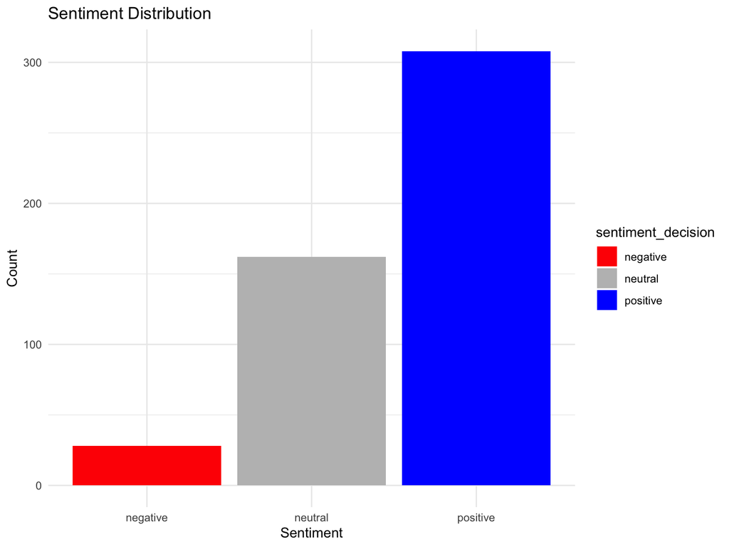

```r
library(ggplot2)
library(readr)

# Plot the distribution of sentiment
ggplot(reviews_sentiments, aes(x = sentiment_decision)) +
  geom_bar(aes(fill = sentiment_decision)) +
  theme_minimal() +
  labs(title = "Sentiment Distribution",
       x = "Sentiment",
       y = "Count") +
  scale_fill_manual(values = c("positive" = "blue", "negative" = "red", "not rated" = "green", "neutral" = "grey"))
```

```r
# Assuming that your sentiment analysis results are in a column called 'sentiment_decision'
```

Based on graph above, here is the analysis:

- **Dominance of Positive Sentiments**: The blue bar representing positive sentiments is the tallest, indicating that the majority of the reviews analyzed have a positive sentiment.
- **Fewer Neutral Sentiments**: The neutral sentiment, depicted by the grey bar, is less frequent than positive but more than negative, suggesting that a moderate number of reviews are neither positive nor negative.
- **Lowest Negative Sentiments**: The red bar for negative sentiments is the shortest, showing that there are comparatively fewer reviews with a negative sentiment.
- **Overall Sentiment Trend**: The sentiment distribution is heavily skewed towards positive sentiments, implying that the subject matter, likely a product or service, is well-received by the majority of reviewers.
- **Potential for Product Strength**: The overwhelming number of positive sentiments may suggest strong satisfaction with the product or service being reviewed.
- **Consideration for Improvement**: The presence of negative sentiments, even though they are few, may provide valuable feedback for areas of improvement.
- **Sentiment Balance**: The neutral sentiments indicate that a certain portion of reviewers may have ambivalent or mixed feelings about the subject.

# Conclusion

The project’s analysis of audiobook data revealed several key findings:

- **User Preferences**:
  - There is a preference for audiobooks that are approximately nine hours long, which fits within the typical user’s time constraints for content consumption.
- **High Ratings**:
  - Audiobooks are generally well-received, with high ratings averaging 4.84, indicating strong user satisfaction.
- **Concentration of Popularity**:
  - Ratings are concentrated among a select number of titles, showing a trend where certain audiobooks are more popular and engaging than others.
- **Audiobook Length vs. Ratings**:
  - A minor negative correlation exists between the length of an audiobook and its ratings, suggesting that factors other than length are more influential in user satisfaction.
- **Impact of Industry Figures**:
  - Authors and narrators who receive higher ratings have a significant impact on the audiobook market, emphasizing the importance of key industry figures.
- **Sentiment Analysis**:
  - The sentiment towards audiobooks is predominantly positive, though there is a notable minority of negative reviews, which provides an opportunity for improvement.

These insights can inform stakeholders in the audiobook industry, guiding decisions on production, marketing, and strategic positioning to enhance the overall user experience and market presence.